- **Title: Working example 3**
- **Output: html_document**
- **Reference: A guide to test association between Polygenic Risk Scores and psychological and psychiatric traits: practical examples**
- **Authors: Itziar Irigoien, Patricia Mas, Sergi Papiol, Neus Barrantes-Vidal, Araceli Rosa, and Concepción Arenas**

## Working example 3

- **data reading**

```r
dat <- read.table("WExample3.csv", header=TRUE, sep=";", dec=",")
names(dat) #
```

```
##  [1] "Sex"        "Diagnostic" "Age"        "Trait"      "PRS.1"
##  [6] "PRS.2"      "PRS.3"      "PRS.4"      "PRS.5"      "PRS.6"
## [11] "PRS.7"      "PRS.8"      "PRS.9"      "PC1"        "PC2"
```

- **do not forget to declare the categorical variables as factors**

```r
dat$Sex <- as.factor(dat$Sex)
dat$Diagnostic <- as.factor(dat$Diagnostic)
```

## 1. What full model should be considered?

- **First, given a particular PRS (named PRS.i), consider all the possible full models:**
- **FMW I : Trait versus PRS.i + Sex + Diagnostic + Age + PC1 + PC2**
- **FMSex: Trait versus PRS.i + Sex + PRS.i · Sex + Diagnostic + Age + PC1 + PC2**
- **FMDiagnostic: Trait versus PRS.i + Sex + Diagnostic + PRS.i · Diagnostic + Age + PC1 + PC2**
- **FMSex/Diagnostic: Trait versus PRS.i + Sex + PRS.i · Sex + Diagnostic + PRS.i · Diagnostic + Age + PC1 + PC2**

## 2. How to make a PRS ranking to find the important ones?

- **As is described in the paper, for each model, calculate the coefficient of determination $R^2$ and calculate the sum: $S = R^2_{WI} + R^2_{Sex} + R^2_{Diagnostic} + R^2_{Sex \cdot Diagnostic}$.**
- **According to S, list the PRSs in decreasing order:**

```r
out <- orderR2(dat, yname="Trait", prsname = "PRS.")
head(out)
```

```
##          Model1    Model2    Model3    Model4       Sum
## PRS.1 0.1906479 0.2106171 0.1928382 0.2117647 0.8058678
## PRS.3 0.1933149 0.1972267 0.1937877 0.1976130 0.7819423
## PRS.4 0.1815838 0.1893220 0.1815840 0.1893272 0.7418170
## PRS.5 0.1734391 0.1896543 0.1737373 0.1919494 0.7287801
## PRS.2 0.1536939 0.1924057 0.1653767 0.2020034 0.7134798
## PRS.7 0.1526951 0.1747579 0.1617509 0.1797416 0.6689455
```

```r
write.csv2(out,file="WExample1_Ordered_PRS.csv")
```

- **Plot the sum of coefficients of determination $S_{R^2}$. Lines: in blue the median; in black the mean.**

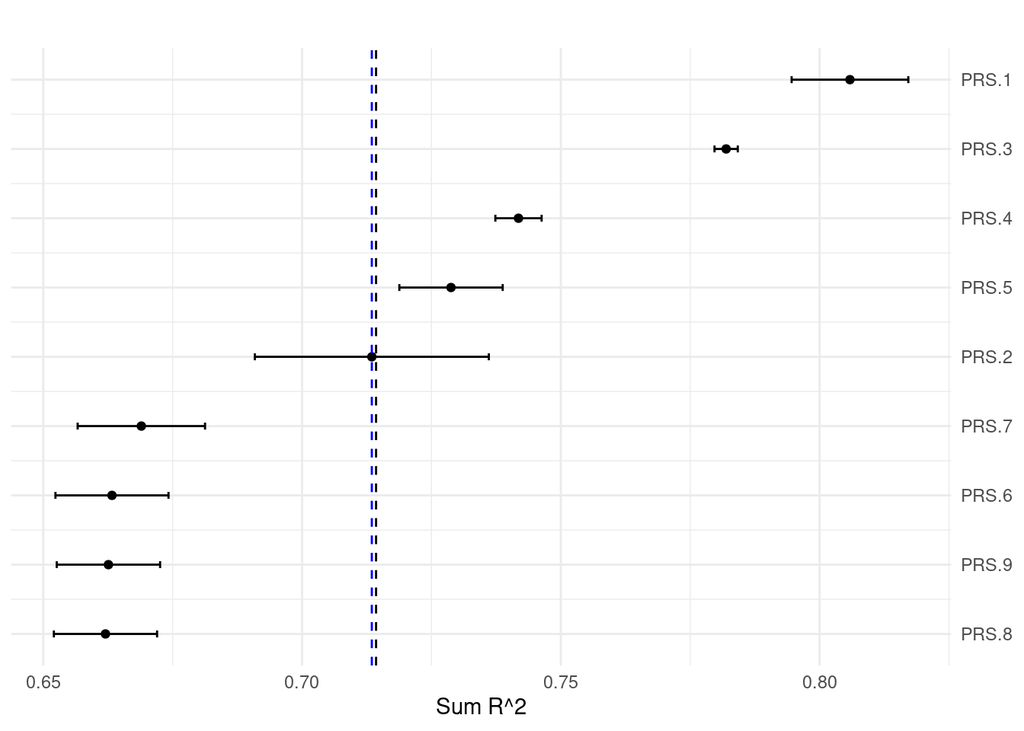

```r
out <- data.frame(out)
nPRS <- dim(out)[1]
select <- grep("Model", names(out), value=FALSE)
out$effect <- out$Sum
sds <- apply(out[, select], 1, sd)
out$lower <- out$effect - sds
out$upper <- out$effect + sds
out$rank <- nPRS:1

n <- dim(out)[1]
ggplot(data=out, aes(y=rank, x=effect, xmin=lower, xmax=upper)) +
  geom_point() +
  geom_errorbarh(height=.1) +
  scale_y_continuous(name=NULL, breaks= n:1, labels=row.names(out), position="right") +
  labs(title='', x='Sum R^2', y = 'PRS') +
  geom_vline(xintercept=mean(out$effect), color='black', linetype='dashed') +
  geom_vline(xintercept=median(out$effect), color='blue', linetype='dashed') +
  theme_minimal()
```

- **According to the obtained results, first PRS.1 is selected to analyze its association with the Trait.**

## 3. Which model, of all the possible ones, should be used?

- **The following figure represents the scatter plot of Trait versus PRS.1 separated by Sex and Diagnostic groups.**

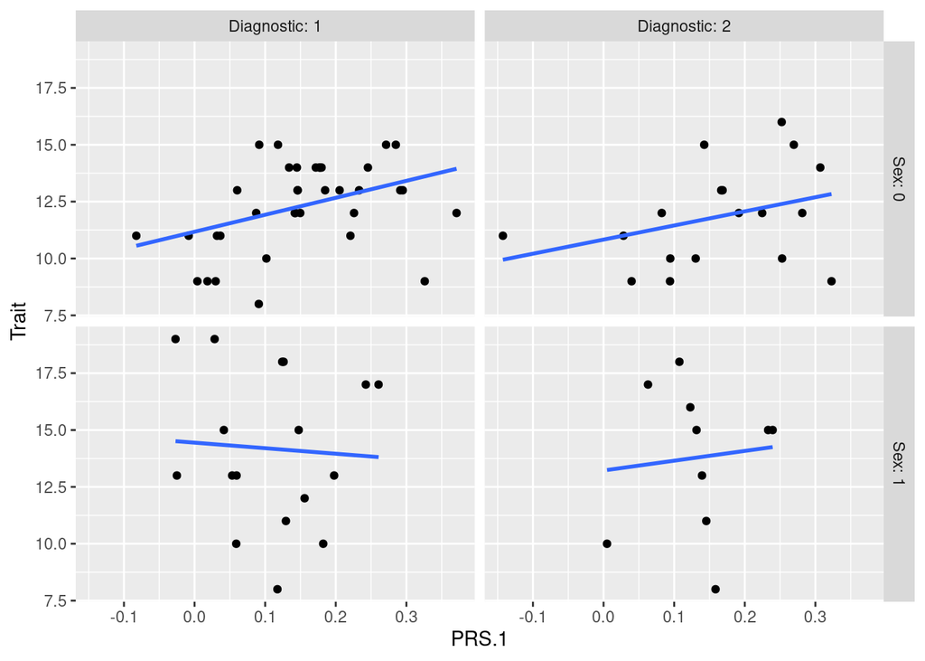

```r
ggplot(dat, aes(x=PRS.1, y=Trait)) +
  geom_point() +
  geom_smooth(method=lm, se=FALSE)+
  facet_grid(Sex ~ Diagnostic, labeller=label_both)
```

- **The plots suggest that the interaction between the PRS.1 and sex is relevant. Thus, we set the full model candidate (FM): $Trait \sim PRS + Sex + Diagnostic + PRS\cdot Sex + PC1 +PC2$.**

### 4. For a continuous trait, what steps should be followed for a correct analysis?

- **4.1. How is the candidate model validated?**
- **First, we validate the normality of the errors and the constant variance conditions (see the figures and the results of Shapiro test and Levene test).**

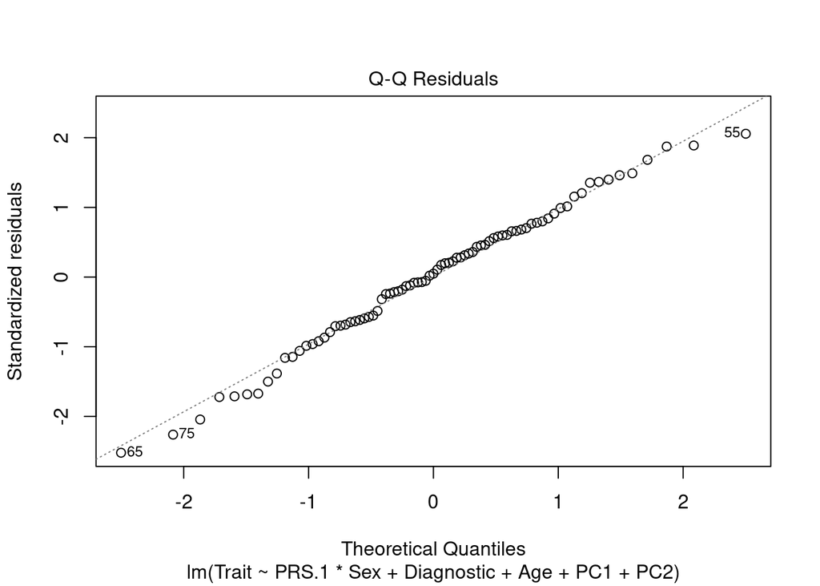

```r
#model
FM <- lm(Trait ~ PRS.1*Sex + Diagnostic + Age + PC1 + PC2, data=dat)
#qq-plot for normality
plot(FM,2)
```

```r
#Shapiro-Wilk test
shapiro.test(FM$residuals)
```

```
##
##  Shapiro-Wilk normality test
##
## data:  FM$residuals
## W = 0.98615, p-value = 0.5353
```

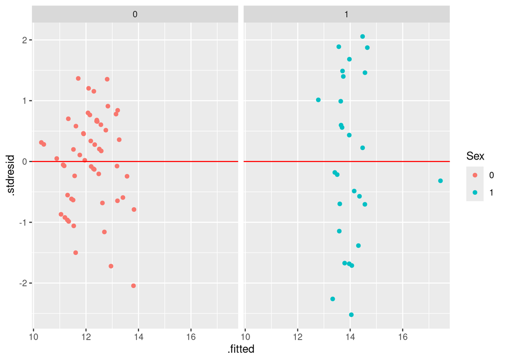

```r
#plot for variances
d <- fortify(FM)
ggplot(d,aes(x=.fitted, y=.stdresid, colour=Sex)) + geom_point() + geom_hline(yintercept=0, col="red")+
  facet_wrap(.~Sex)
```

```r
#Levene's test
leveneTest(.stdresid ~ Sex, data=d)
```

```
## Levene's Test for Homogeneity of Variance (center = median)
##       Df F value    Pr(>F)
## group  1  15.673 0.0001636 ***
##       79
## ---
## Signif. codes:  0 '***' 0.001 '**' 0.01 '*' 0.05 '.' 0.1 ' ' 1
```

- **It seems that homocedasticity does not hold.**
- **4.2. What can be done if any validation condition fails?**
- **We have two approaches to assess the possible association with PRS.1 and the Trait: try a Box-Cox transformation or perform a weighted permutation test.**
- **First, we try a Box-Cox transformation of the dependent variable:**
  - **Determine the lambda value.**

```r
b <- boxcox(FM)
```

[figure not shown]

```r
# Exact lambda
lambda <- b$x[which.max(b$y)]
lambda
```

```
## [1] 0.6666667
```

- **Transform the dependent variable and establish the new model.**

```r
dat$newTrait <- (dat$Trait ^ lambda - 1) / lambda
FM <- lm(newTrait ~ PRS.1*Sex + Diagnostic + Age + PC1 + PC2, data=dat)
```

- **Check the normality and homocedasticity conditions.**

```r
#Shapiro-Wilk test
shapiro.test(FM$residuals)
```

```
##
##  Shapiro-Wilk normality test
##
## data:  FM$residuals
## W = 0.98029, p-value = 0.2465
```

```r
#Levene's test
d <- fortify(FM)
leveneTest(.stdresid ~ Sex, data=d)
```

```
## Levene's Test for Homogeneity of Variance (center = median)
##       Df F value    Pr(>F)
## group  1  13.368 0.0004595 ***
##       79
## ---
## Signif. codes:  0 '***' 0.001 '**' 0.01 '*' 0.05 '.' 0.1 ' ' 1
```

- **In this case, the suggested Box-Cox transformation with $\lambda = 0.667$ does not solve the heteroscedasticity problem. For this reason we perform a weighted-permutation test.**

```r
NM <- lm(Trait ~ Sex + Diagnostic + Age + PC1+PC2, data=dat)
FM <- lm(Trait ~ PRS.1*Sex + Diagnostic + Age + PC1+PC2, data=dat)
outperm <- dR2(NullModel=NM, FullModel=FM, B=1000, seed=165,  weights=TRUE)
outperm
```

```
## $dR2
## [1] 0.09217286
##
## $pvalue
## [1] 0
```

- **We observe an increase of 0.092 in the coefficient of determination when the PRS.1 is included in the model and the permutation test indicates it is significant.**
- **Last step: We move to the next PRS.**